# Parasite Reproductive Success in Small Populations

Saturating Transmission, Superinfection, and $R_0$

David L. Smith, Richard Steketee

People who followed the COVID-19 news became familiar with the concept of the basic reproductive number, $R_0$. During an outbreak, $R_0$ is the average number of people who would get infected by each infected person. $R_0$ is a useful way of describing transmission because it defines a threshold condition for epidemics: if $R_0 < 1$, then over time, the epidemic will tend to die out. For COVID, the hope was that enough people would become immune that eventually the population would achieve herd immunity. The hard lesson learned was that people could be reinfected with the virus. Other biological details matter, so care must be taken in using $R_0$ to guide policies.

The first time $R_0$ was used to describe an infectious disease was in 1952, when Macdonald developed a formula to describe malaria transmission [1]. When some malaria epidemiologists took Macdonald’s formula to the field in 1953, they estimated $R_0$ to be between 2,000 and 5,000 in the Usambara Mountains of Tanzania [2]. Compared with other infectious diseases, this estimate might seem outrageously high. How is it possible to infect a thousand people in a rural setting, where there might be a few hundred people in the immediate area?

Macdonald’s formula for $R_0$ counts the number of *infections* that would occur, per infection. It was based on a description of human blood feeding and potential transmission by mosquito and human populations. The formula counts either the number of infected mosquitoes per infected mosquito, or the number of infected humans per infected human. The expected number of infections arising is the same, whether the counting starts from a human or from a mosquito. When the human population size is much larger than $R_0$, the number of human infections arising would be approximately the same as the number of different people getting infected. In small human populations, that might not always be true. Some people could get infected more than once, so the number of people who got infected would be less than the number of infections arising.

Most of the terms in Macdonald’s formula for $R_0$ describe *vectorial capacity* or alternatively the *daily reproductive rate*, which was defined as the number of infective bites that would eventually arise from all the mosquitoes that would blood feed on a single human on a single day, assuming the human infected every one of those mosquitoes [3]. The assumption about humans being *perfectly infectious* was done to remove considerations about the complexity of malaria infections in humans: vectorial capacity is only about the vectors. The human transmitting capacity is equally important for transmission. After some careful thinking about how to count up infectiousness in humans, it appears that untreated, non-immune humans are partially infectious over the time course of an infection for an amount of time that adds up to about 30-40 perfectly infectious days [4].

A concept that is closely related to vectorial capacity is the *entomological inoculation rate* (or EIR), the number of infective bites that a person receives on a single day. After accounting for the fact that the human population is not even close to being perfectly infectious, the average number of infective bites **arising**, per person, per day (*i.e.*, vectorial capacity) should be approximately equal to the number of infective bites **received**, per person, per day (*i.e.* EIR) [5].

Estimates of the EIR are highly variable, and thus so is vectorial capacity. Using information about the capacity of humans to transmit, and the net infectiousness of human populations, we can use the estimated EIR to develop estimates of vectorial capacity and $R_0$ [6]. Using this method, the highest estimates of the EIR are well above a thousand, but there is substantial uncertainty. Those original estimates of $R_0$ – as a way of counting infections arising – don’t seem so absurd.

Since malaria is transmitted by mosquitoes, when mosquito population densities are extremely high, the number of infections arising can be larger than the number of people who are around to get infected. Malaria is different from other infectious diseases in another way – being infected with malaria doesn’t prevent new infections from occurring. Superinfection – when a person who is already infected gets infected again – is common. Redundant infections can occur, but how should they be counted when transmission is so high that it saturates?

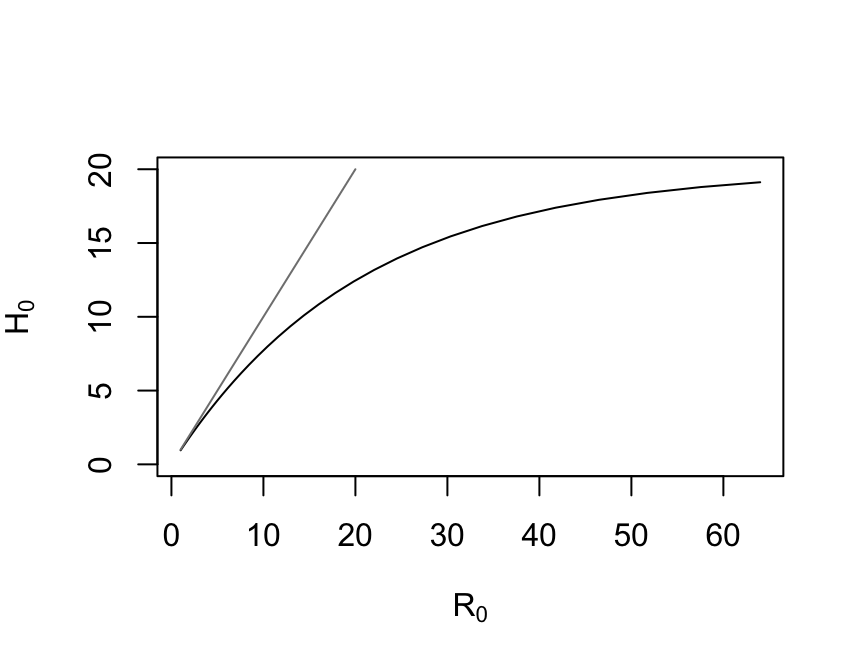

The number of people who would be infected by one person, $H_0$, on an island with 21 people

How do we count up infections in small populations? Since Macdonald’s formula for $R_0$ actually describes the number of *infections* that would arise, we can use it to compute how many different humans would become infected in small populations. If each new infections is distributed randomly among $H$ people, then the probability a person would not get infected by any one of them is:

$$\left(1-\frac{1}{H}\right)^{R_0}$$
To avoid confusion, we’ll let $H_0$ be the number of unique individuals infected. The expected number of uniquely infected individuals, not counting the index case, is a function of both $R_0$ and $H$. If there are $H$ people, and we don’t count the index case, then there are $H-1$ others who could be infected:

$$H_0(R_0, H) = (H-1) \left[ 1-
\left(1-\frac{1}{H}\right)^{R_0}\right]$$

We can use this formula to describe what happens in small populations (Figure 1). Imagine, for example, that there are twenty-one people living on an island. If one person has malaria, there are only twenty others who could become infected. When $R_0=20$, $H_0 \approx 12.5$.

Using the same formulas, we can remake the graph to show what it looks like as we change $R_0$ for $H=100$ and $H=1000$ (Figure 2). When $H=100$ but $R_0 > 300$, almost everyone would get infected by the index case. In this case, transmission gets saturated.

When needed, we can compute $H_0$ to understand the effects of saturating transmission. The formula we presented here works when parasites are randomly mixing in a small population. If we wanted to be more careful about estimating the relationship between the number of infections and the number of different people infected, we would need to take into account the heterogeneous distribution of humans and mosquitoes and the way humans and mosquitoes move around. The formulas have been developed, but the math is not simple [7]. Software to compute the expected number of infected people is part of a software package called `exDE`.

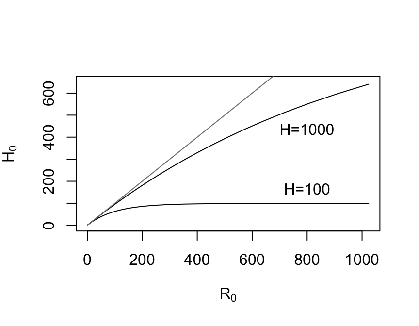

The relationship between $R_0$ and $H_0$ in two populations of different sizes.

Macdonald’s formula for $R_0$ describes the number of human infections arising from a single human. For parasite transmission among humans, the result is saturation and superinfection, and it could have some effects on the epidemiology. Macdonald’s formula for $R_0$ also describes the number of mosquito infections that would arise from a single infected mosquito. Because mosquitoes tend to live short lives, saturation is comparatively unimportant [6]. Even in rural populations with very small human populations, Macdonald’s formula is a good way to understand vector control; $R_0$ tells us how much transmission by mosquitoes would have to be reduced to eliminate malaria. Even if populations are small, $R_0$ works well as a way of describing transmission intensity and as a threshold criterion. Whether $H=100$ or $H=1000$, transmission by mosquitoes would have to be reduced by a factor that was higher than $R_0$ to eliminate malaria.

**References**

1.

Macdonald G. The analysis of equilibrium in malaria. Trop Dis Bull. 1952;49: 813–829.

2.

Davidson G, Draper CC. Field studies of some of the basic factors concerned in the transmission of malaria. Trans R Soc Trop Med Hyg. 1953;47: 522–535.

3.

Garrett-Jones C. Prognosis for interruption of malaria transmission through assessment of the mosquito’s vectorial capacity. Nature. 1964;204: 1173–1175.

4.

Johnston GL, Smith DL, Fidock DA. Malaria’s missing number: Calculating the human component of R$_{0}$ by a within-host mechanistic model of *plasmodium falciparum* infection and transmission. PLoS Comput Biol. 2013;9: e1003025.

5.

Smith DL, McKenzie FE. Statics and dynamics of malaria infection in *Anopheles* mosquitoes. Malar J. 2004;3: 13.

6.

Smith DL, McKenzie FE, Snow RW, Hay SI. Revisiting the basic reproductive number for malaria and its implications for malaria control. PLoS Biol. 2007;5: e42.

7.

Wu SL, Henry JM, Citron DT, Mbabazi Ssebuliba D, Nakakawa Nsumba J, Sanchez C HM, et al. Spatial dynamics of malaria transmission. Overleaf. University of Washington; 2022.